# Convert JSON Nirvana Output to data Tibble

Karim Mezhoud

2023-02-28

[figure not shown]

# 1 How to run Nirvana ([Tutorial](https://support.illumina.com/content/dam/illumina-support/help/Illumina_DRAGEN_Bio_IT_Platform_v3_7_1000000141465/Content/SW/Informatics/Dragen/Nirvana_DownloadData_fDG.htm))

## 1.1 Download the files for genome Assembly

```bash
cd /staging/examples/outputs
mkdir Data
# Download the files for a genome assembly.
/opt/edico/share/nirvana/Downloader --ga GRCh38 --out ~/Data
```

You can use the same command to resynchronize the data sources with the Nirvana servers, including the following actions:

- Remove obsolete files, such as old versions of data sources, from the output directory.
- Download newer files.

The following is the created output:

```bash
Downloader (c) 2020 Illumina, Inc.

Stromberg, Roy, Lajugie, Jiang, Li, and Kang 3.9.1-0-gc823805

---------------------------------------------------------------------------

- downloading manifest... 37 files.

- downloading file metadata:

- finished (00:00:00.8).

- downloading files (22.123 GB):

- downloading 1000_Genomes_Project_Phase_3_v3_plus_refMinor.rma.idx (GRCh38)

- downloading MITOMAP_20200224.nsa.idx (GRCh38)

- downloading ClinVar_20200302.nsa.idx (GRCh38)

- downloading REVEL_20160603.nsa.idx (GRCh38)

- downloading phyloP_hg38.npd.idx (GRCh38)

- downloading ClinGen_Dosage_Sensitivity_Map_20200131.nsi (GRCh38)

- downloading MITOMAP_SV_20200224.nsi (GRCh38)

- downloading dbSNP_151_globalMinor.nsa.idx (GRCh38)

- downloading ClinGen_Dosage_Sensitivity_Map_20190507.nga (GRCh38)

- downloading PrimateAI_0.2.nsa.idx (GRCh38)

- downloading ClinGen_disease_validity_curations_20191202.nga (GRCh38)

- downloading 1000_Genomes_Project_Phase_3_v3_plus.nsa.idx (GRCh38)

- downloading SpliceAi_1.3.nsa.idx (GRCh38)

- downloading dbSNP_153.nsa.idx (GRCh38)

- downloading TOPMed_freeze_5.nsa.idx (GRCh38)

- downloading MITOMAP_20200224.nsa (GRCh38)

- downloading gnomAD_2.1.nsa.idx (GRCh38)

- downloading ClinGen_20160414.nsi (GRCh38)

- downloading gnomAD_gene_scores_2.1.nga (GRCh38)

- downloading 1000_Genomes_Project_(SV)_Phase_3_v5a.nsi (GRCh38)

- downloading MultiZ100Way_20171006.pcs (GRCh38)

- downloading 1000_Genomes_Project_Phase_3_v3_plus_refMinor.rma (GRCh38)

- downloading ClinVar_20200302.nsa (GRCh38)

- downloading OMIM_20200409.nga (GRCh38)

- downloading Both.transcripts.ndb (GRCh38)

- downloading REVEL_20160603.nsa (GRCh38)

- downloading PrimateAI_0.2.nsa (GRCh38)

- downloading dbSNP_151_globalMinor.nsa (GRCh38)

- downloading Both.sift.ndb (GRCh38)

- downloading Both.polyphen.ndb (GRCh38)

- downloading Homo_sapiens.GRCh38.Nirvana.dat

- downloading 1000_Genomes_Project_Phase_3_v3_plus.nsa (GRCh38)

- downloading phyloP_hg38.npd (GRCh38)

- downloading SpliceAi_1.3.nsa (GRCh38)

- downloading TOPMed_freeze_5.nsa (GRCh38)

- downloading dbSNP_153.nsa (GRCh38)

- downloading gnomAD_2.1.nsa (GRCh38)

- finished (00:04:10.1).

Description Status

---------------------------------------------------------------------------

1000_Genomes_Project_(SV)_Phase_3_v5a.nsi (GRCh38) OK

1000_Genomes_Project_Phase_3_v3_plus.nsa (GRCh38) OK

1000_Genomes_Project_Phase_3_v3_plus.nsa.idx (GRCh38) OK

1000_Genomes_Project_Phase_3_v3_plus_refMinor.rma (GRCh38) OK

1000_Genomes_Project_Phase_3_v3_plus_refMinor.rma.idx (... OK

Both.polyphen.ndb (GRCh38) OK

Both.sift.ndb (GRCh38) OK

Both.transcripts.ndb (GRCh38) OK

ClinGen_20160414.nsi (GRCh38) OK

ClinGen_Dosage_Sensitivity_Map_20190507.nga (GRCh38) OK

ClinGen_Dosage_Sensitivity_Map_20200131.nsi (GRCh38) OK

ClinGen_disease_validity_curations_20191202.nga (GRCh38) OK

ClinVar_20200302.nsa (GRCh38) OK

ClinVar_20200302.nsa.idx (GRCh38) OK

Homo_sapiens.GRCh38.Nirvana.dat OK

MITOMAP_20200224.nsa (GRCh38) OK

MITOMAP_20200224.nsa.idx (GRCh38) OK

MITOMAP_SV_20200224.nsi (GRCh38) OK

MultiZ100Way_20171006.pcs (GRCh38) OK

OMIM_20200409.nga (GRCh38) OK

PrimateAI_0.2.nsa (GRCh38) OK

PrimateAI_0.2.nsa.idx (GRCh38) OK

REVEL_20160603.nsa (GRCh38) OK

REVEL_20160603.nsa.idx (GRCh38) OK

SpliceAi_1.3.nsa (GRCh38) OK

SpliceAi_1.3.nsa.idx (GRCh38) OK

TOPMed_freeze_5.nsa (GRCh38) OK

TOPMed_freeze_5.nsa.idx (GRCh38) OK

dbSNP_151_globalMinor.nsa (GRCh38) OK

dbSNP_151_globalMinor.nsa.idx (GRCh38) OK

dbSNP_153.nsa (GRCh38) OK

dbSNP_153.nsa.idx (GRCh38) OK

gnomAD_2.1.nsa (GRCh38) OK

gnomAD_2.1.nsa.idx (GRCh38) OK

gnomAD_gene_scores_2.1.nga (GRCh38) OK

phyloP_hg38.npd (GRCh38) OK

phyloP_hg38.npd.idx (GRCh38) OK

---------------------------------------------------------------------------

Peak memory usage: 52.3 MB

Time: 00:04:12.2
```

## 1.2 Annotae Files and generate `Json` output

We can use `HiSeq.10000.json.gz` file, generated in previous section, or download it from github.

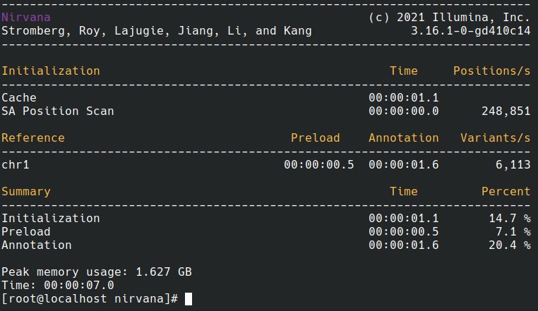

```bash
# download and example of vcf.gz file
curl -O https://raw.githubusercontent.com/HelixGrind/DotNetMisc/master/TestFiles/HiSeq.10000.vcf.gz

#generate json output
/opt/edico/share/nirvana/Nirvana -c ~/Data/Cache/GRCh38/Both \
-r ~/Data/References/Homo_sapiens.GRCh38.Nirvana.dat \
--sd ~/Data/SupplementaryAnnotation/GRCh38 \
-i HiSeq.10000.vcf.gz -o HiSeq.10000
```

# 2 JSON Structure

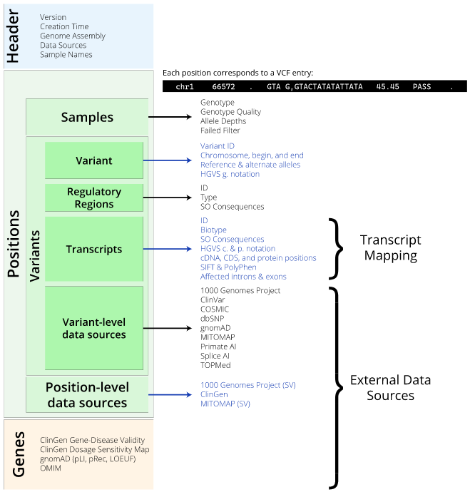

# 3 R Environment

[Link](https://github.com/Illumina/NirvanaDocumentation/blob/master/static/files/parse-nirvana-json-r.ipynb) to Illumina parsing style.

```bash
# Load  an example of Nirvana json file output
wget https://illumina.github.io/NirvanaDocumentation/files/HiSeq.10000.json.gz
```

## 3.1 Extact Header, Positions and Genes Objects from `json.gz` file

- The first line in the `JSON` file in the `header` line:

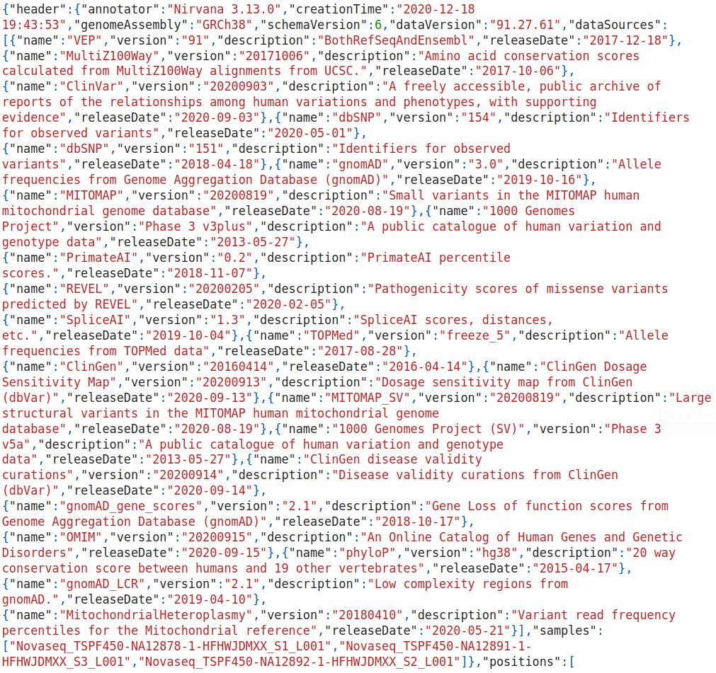

```r
require(jsonlite)
require(DT)
require(tidyr)
require(dplyr)

file = gzfile('HiSeq.10000.json.gz', 'rt')
#file = gzfile('ceph_trio_test.json.gz', 'rt')

header = ''
positions = c()
genes = c()
is_header_line = TRUE
is_position_line = FALSE
is_gene_line = FALSE
gene_section_line = '],"genes":['
end_line = ']}'
position_count = 0
gene_count = 0
while ( TRUE ) {
    line = readLines(file, n = 1)
    trim_line = trimws(line)
    if ( is_header_line ) {
        ## only keep the "header" field content from the line
        header = substr(trim_line, 11, nchar(trim_line)-14)
        is_header_line = FALSE
        is_position_line = TRUE
        next
    }
    if ( trim_line == gene_section_line ) {
        is_gene_line = TRUE
        is_position_line = FALSE
        next
    }
    else if ( trim_line == end_line ) {
        break
    }
    else {
        if ( is_position_line ) {
            ## remove the trailing ',' if there is
            positions = c(positions, sub(",$", "", trim_line))
            position_count = position_count + 1
        }
        if ( is_gene_line ) {
            ## remove the trailing ',' if there is
            genes = c(genes, sub(",$", "", trim_line))
            gene_count = gene_count + 1
        }
    }
}
close(file)

paste0('Header Object_',1:5,": ", fromJSON(header)[1:5])
```

```
## [1] "Header Object_1: Nirvana 3.12.0"
## [2] "Header Object_2: 2020-11-13 17:09:01"
## [3] "Header Object_3: GRCh37"
## [4] "Header Object_4: 6"
## [5] "Header Object_5: 91.27.60"
```

```r
#gsub('"', '', header, fixed=TRUE)
DT::datatable(fromJSON(header)[6][[1]],
              options = list(scrollX = TRUE,
                             columnDefs = list(list(className = 'dt-center', targets = all))
                             ),
              rownames = FALSE, caption = 'Header Object_6')
```

| name | version | description | releaseDate |
| --- | --- | --- | --- |
| VEP | 91 | BothRefSeqAndEnsembl | 2017-12-18 |
| MultiZ100Way | 20150427 | Amino acid conservation scores calculated from MultiZ100Way alignments from UCSC. | 2015-04-27 |
| ClinVar | 20200903 | A freely accessible, public archive of reports of the relationships among human variations and phenotypes, with supporting evidence | 2020-09-03 |
| dbSNP | 154 | Identifiers for observed variants | 2020-05-01 |
| dbSNP | 151 | Identifiers for observed variants | 2018-04-23 |
| gnomAD | 2.1 | Allele frequencies from Genome Aggregation Database (gnomAD) | 2018-10-17 |
| MITOMAP | 20200819 | Small variants in the MITOMAP human mitochondrial genome database | 2020-08-19 |
| 1000 Genomes Project | Phase 3 v5a | A public catalogue of human variation and genotype data | 2013-05-27 |
| PrimateAI | 0.2 | PrimateAI percentile scores. | 2018-11-07 |
| REVEL | 20200205 | Pathogenicity scores of missense variants predicted by REVEL | 2020-02-05 |

[output cut: 12 more lines]

```r
print(paste('number of positions: ', position_count))
```

```
## [1] "number of positions:  9966"
```

```r
print(paste('number of genes: ', gene_count))
```

```
## [1] "number of genes:  77"
```

## 3.2 Convert Positions object to a Tibble

- Followed by the `positions` lines (two positions lines in this case:)

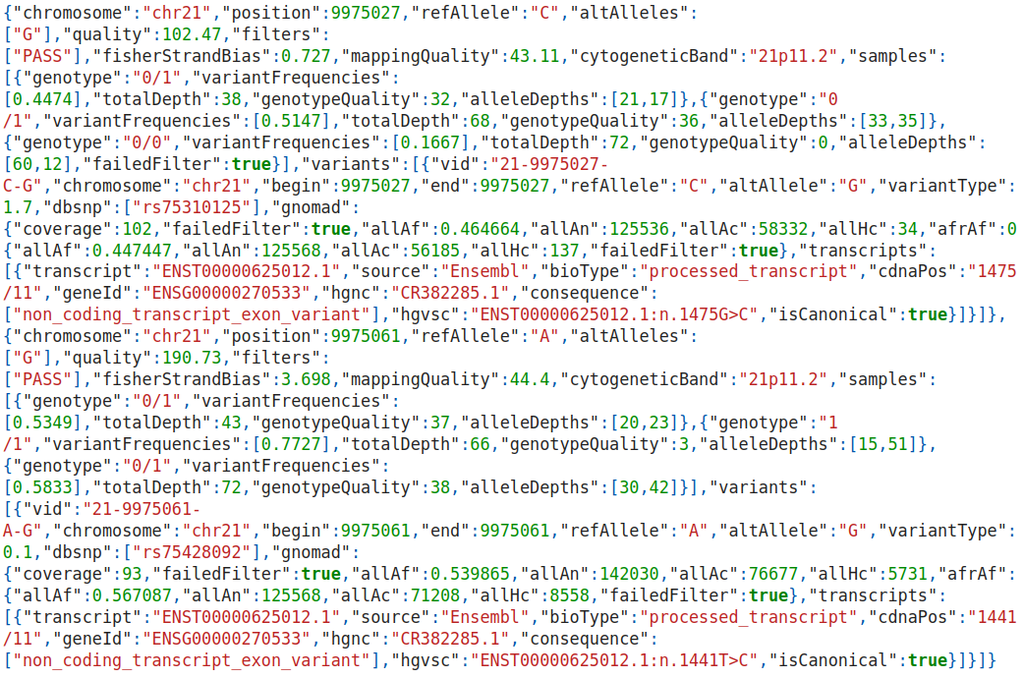

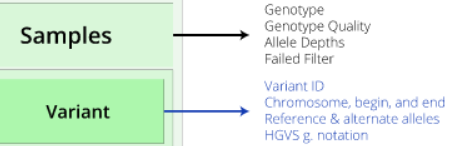

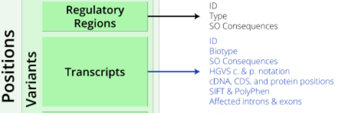

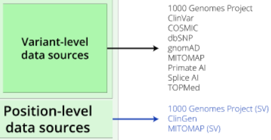

```r
#fromJSON(positions[7]) %>% as.data.frame()  %>% DT::datatable(options = list(scrollX = TRUE), rownames = TRUE)

#bind_rows(fromJSON(positions[7])) %>%
#  tidyr::unnest(cols = c(samples, variants), names_sep = ".") %>%
#  DT::datatable(options = list(scrollX = TRUE), rownames = TRUE)

#fromJSON(positions[1:7])

positions[1:10] |>
  lapply(function(x) dplyr::bind_rows(fromJSON(x)) |>
           tidyr::unnest(cols = c(samples, variants), names_sep = ".")  ) |>
  dplyr::bind_rows(.id = "index") |>
  #tidyr::unnest(c( samples.variantFrequencies, samples.alleleDepths))%>%
  #tidyr::unnest(filters) %>%
  #distinct() %>%
  DT::datatable(options = list(scrollX = TRUE#,
                 #columnDefs = list(list(className = 'dt-center', targets = c(0, 25)))
                ),
                rownames = FALSE
                )
```

| index | chromosome | position | refAllele | altAlleles | quality | filters | strandBias | mappingQuality | cytogeneticBand | samples.genotype | samples.variantFrequencies | samples.totalDepth | samples.genotypeQuality | samples.alleleDepths | variants.vid | variants.chromosome | variants.begin | variants.end | variants.refAllele | variants.altAllele | variants.variantType | variants.hgvsg |
| --- | --- | --- | --- | --- | --- | --- | --- | --- | --- | --- | --- | --- | --- | --- | --- | --- | --- | --- | --- | --- | --- | --- |
| 1 | chr1 | 109 | A | T | 0 | FDRtranche2.00to10.00+ | -1042.18 | 19.2 | 1p36.33 | 0/1 | [0.349] | 308 | 99 | [610, 327] | 1-109-A-T | chr1 | 109 | 109 | A | T | SNV | NC_000001.10:g.109A&gt;T |
| 2 | chr1 | 147 | C | A | 0 | FDRtranche2.00to10.00+ | -76.48 | 20.23 | 1p36.33 | 0/1 | [0.1429] | 118 | 99 | [294, 49] | 1-147-C-A | chr1 | 147 | 147 | C | A | SNV | NC_000001.10:g.147C&gt;A |
| 3 | chr1 | 177 | A | C | 0 | FDRtranche2.00to10.00+ | -140.54 | 17.76 | 1p36.33 | 0/1 | [0.331] | 122 | 99 | [283, 140] | 1-177-A-C | chr1 | 177 | 177 | A | C | SNV | NC_000001.10:g.177A&gt;C |
| 4 | chr1 | 180 | T | C | 0 | FDRtranche2.00to10.00+ | -412.44 | 14.22 | 1p36.33 | 0/1 | [0.2484] | 104 | 99 | [466, 154] | 1-180-T-C | chr1 | 180 | 180 | T | C | SNV | NC_000001.10:g.180T&gt;C |
| 5 | chr1 | 234 | C | T | 0 | FDRtranche2.00to10.00+ | -230.12 | 19.45 | 1p36.33 | 0/1 | [0.2006] | 106 | 99 | [267, 67] | 1-234-C-T | chr1 | 234 | 234 | C | T | SNV | NC_000001.10:g.234C&gt;T |
| 6 | chr1 | 235 | T | A | 0 | FDRtranche2.00to10.00+ | -219.5 | 19.68 | 1p36.33 | 0/1 | [0.1464] | 105 | 99 | [274, 47] | 1-235-T-A | chr1 | 235 | 235 | T | A | SNV | NC_000001.10:g.235T&gt;A |
| 7 | chr1 | 250 | A | C | 22.88 | DPFilter | -23.67 | 21.91 | 1p36.33 | 0/1 | [0.1823] | 70 |  | [148, 33] | 1-250-A-C | chr1 | 250 | 250 | A | C | SNV | NC_000001.10:g.250A&gt;C |
| 7 | chr1 | 250 | A | C | 22.88 | HARD_TO_VALIDATE | -23.67 | 21.91 | 1p36.33 | 0/1 | [0.1823] | 70 |  | [148, 33] | 1-250-A-C | chr1 | 250 | 250 | A | C | SNV | NC_000001.10:g.250A&gt;C |
| 7 | chr1 | 250 | A | C | 22.88 | LowQual | -23.67 | 21.91 | 1p36.33 | 0/1 | [0.1823] | 70 |  | [148, 33] | 1-250-A-C | chr1 | 250 | 250 | A | C | SNV | NC_000001.10:g.250A&gt;C |
| 8 | chr1 | 291 | C | T | 0 | FDRtranche2.00to10.00+ | -160.31 | 20.72 | 1p36.33 | 0/1 | [0.3308] | 32 | 99 | [87, 43] | 1-291-C-T | chr1 | 291 | 291 | C | T | SNV | NC_000001.10:g.291C&gt;T |

[output cut: 2 more lines]

- But it seems we lost data.frame hidden in some cells.
- We look for `gnomad` pattern in positions

```r
# Look for gnomAD infos

# get index of item that have gnomad pattern
grep("gnomad", positions, value = FALSE)
```

```
##   [1]  163  237  288  397  572  585  710  764  901 1016 1031 1067 1072 1085 1097
##  [16] 1215 1258 1281 1285 1295 1323 1328 1357 1364 1366 1407 1657 1768 1781 1957
##  [31] 1978 2040 2062 2127 2140 2145 2162 2182 2240 2270 2304 2334 2406 2426 2594
##  [46] 2629 2734 2762 2835 2840 2928 2940 2998 3056 3087 3209 3211 3255 3261 3435
##  [61] 3449 3472 3575 3639 3666 3764 3765 3793 3895 3907 3924 3977 4067 4079 4178
##  [76] 4206 4221 4235 4265 4281 4300 4316 4346 4361 4444 4445 4530 4534 4557 4561
##  [91] 4582 4584 4595 4639 4651 4677 4684 4687 4688 4695 4727 4750 4780 4794 4805
## [106] 4806 4823 4832 4918 5156 5183 5208 5243 5325 5409 5480 5662 5665 5750 5755
## [121] 5838 5920 5967 6042 6061 6115 6256 6363 6408 6443 6619 6669 6807 6825 6853
## [136] 7106 7329 7542 7573 7660 7748 7860 8084 8103 8115 8136 8150 8162 8321 8480
## [151] 8514 8808 8862 8986 9375 9560 9566 9634 9642 9664 9681 9728
```

`gnomad` info start from index 163.

- Display `gnomad` info

```r
grep("gnomad", positions[163], value = TRUE)
```

```
## [1] "{\"chromosome\":\"chr1\",\"position\":91835,\"refAllele\":\"T\",\"altAlleles\":[\"C\"],\"quality\":60.94,\"filters\":[\"PASS\"],\"strandBias\":-10,\"mappingQuality\":20.01,\"cytogeneticBand\":\"1p36.33\",\"samples\":[{\"genotype\":\"0/1\",\"variantFrequencies\":[0.4267],\"totalDepth\":33,\"a…
```

- Display the structure of samples and variants columns.

```r
bind_rows(fromJSON(positions[163])) |>
  select(samples, variants) %>% str()
```

```
## tibble [1 × 2] (S3: tbl_df/tbl/data.frame)
##  $ samples :'data.frame':    1 obs. of  4 variables:
##   ..$ genotype          : chr "0/1"
##   ..$ variantFrequencies:List of 1
##   .. ..$ : num 0.427
##   ..$ totalDepth        : int 33
##   ..$ alleleDepths      :List of 1
##   .. ..$ : int [1:2] 43 32
##  $ variants:'data.frame':    1 obs. of  12 variables:
##   ..$ vid        : chr "1-91835-T-C"
##   ..$ chromosome : chr "chr1"
##   ..$ begin      : int 91835
##   ..$ end        : int 91835
##   ..$ refAllele  : chr "T"
##   ..$ altAllele  : chr "C"
##   ..$ variantType: chr "SNV"
##   ..$ hgvsg      : chr "NC_000001.10:g.91835T>C"
##   ..$ dbsnp      :List of 1
##   .. ..$ : chr "rs1030792189"
##   ..$ gnomad     :'data.frame':  1 obs. of  44 variables:
##   .. ..$ coverage     : int 14
##   .. ..$ allAf        : num 0.000276
##   .. ..$ allAn        : int 10860
##   .. ..$ allAc        : int 3
##   .. ..$ allHc        : int 0
##   .. ..$ afrAf        : num 0.000518
##   .. ..$ afrAn        : int 5796
##   .. ..$ afrAc        : int 3
##   .. ..$ afrHc        : int 0
##   .. ..$ amrAf        : int 0
##   .. ..$ amrAn        : int 372
##   .. ..$ amrAc        : int 0
##   .. ..$ amrHc        : int 0
##   .. ..$ easAf        : int 0
##   .. ..$ easAn        : int 1016
##   .. ..$ easAc        : int 0
##   .. ..$ easHc        : int 0
##   .. ..$ finAf        : int 0
##   .. ..$ finAn        : int 588
##   .. ..$ finAc        : int 0
```

[output cut: 29 more lines]

```
##   .. ..$ failedFilter: logi TRUE
##   ..$ transcripts:List of 1
##   .. ..$ :'data.frame':  3 obs. of  9 variables:
##   .. .. ..$ transcript : chr [1:3] "ENST00000466430.1" "ENST00000495576.1" "ENST00000477740.1"
##   .. .. ..$ source     : chr [1:3] "Ensembl" "Ensembl" "Ensembl"
##   .. .. ..$ bioType    : chr [1:3] "lincRNA" "lincRNA" "lincRNA"
##   .. .. ..$ introns    : chr [1:3] "3/3" NA NA
##   .. .. ..$ geneId     : chr [1:3] "ENSG00000238009" "ENSG00000239945" "ENSG00000238009"
##   .. .. ..$ hgnc       : chr [1:3] "AL627309.1" "AL627309.3" "AL627309.1"
##   .. .. ..$ consequence:List of 3
##   .. .. .. ..$ : chr [1:2] "intron_variant" "non_coding_transcript_variant"
##   .. .. .. ..$ : chr "upstream_gene_variant"
##   .. .. .. ..$ : chr "downstream_gene_variant"
##   .. .. ..$ hgvsc      : chr [1:3] "ENST00000466430.1:n.414-206A>G" NA NA
##   .. .. ..$ isCanonical: logi [1:3] NA TRUE TRUE
```

- Try to unnest variants column

```r
 bind_rows(fromJSON(positions[163]))$variants |>
  unnest(cols = c(dbsnp, gnomad, topmed, transcripts), names_sep = ".") |>
  DT::datatable(options = list(scrollX = TRUE))
```

|  | vid | chromosome | begin | end | refAllele | altAllele | variantType | hgvsg | dbsnp | gnomad.coverage | gnomad.allAf | gnomad.allAn | gnomad.allAc | gnomad.allHc | gnomad.afrAf | gnomad.afrAn | gnomad.afrAc | gnomad.afrHc | gnomad.amrAf | gnomad.amrAn | gnomad.amrAc | gnomad.amrHc | gnomad.easAf | gnomad.easAn | gnomad.easAc | gnomad.easHc | gnomad.finAf | gnomad.finAn | gnomad.finAc | … |
| --- | --- | --- | --- | --- | --- | --- | --- | --- | --- | --- | --- | --- | --- | --- | --- | --- | --- | --- | --- | --- | --- | --- | --- | --- | --- | --- | --- | --- | --- | --- |
| 1 | 1-91835-T-C | chr1 | 91835 | 91835 | T | C | SNV | NC_000001.10:g.91835T&gt;C | rs1030792189 | 14 | 0.000276 | 10860 | 3 | 0 | 0.000518 | 5796 | 3 | 0 | 0 | 372 | 0 | 0 | 0 | 1016 | 0 | 0 | 0 | 588 | 0 | … |
| 2 | 1-91835-T-C | chr1 | 91835 | 91835 | T | C | SNV | NC_000001.10:g.91835T&gt;C | rs1030792189 | 14 | 0.000276 | 10860 | 3 | 0 | 0.000518 | 5796 | 3 | 0 | 0 | 372 | 0 | 0 | 0 | 1016 | 0 | 0 | 0 | 588 | 0 | … |
| 3 | 1-91835-T-C | chr1 | 91835 | 91835 | T | C | SNV | NC_000001.10:g.91835T&gt;C | rs1030792189 | 14 | 0.000276 | 10860 | 3 | 0 | 0.000518 | 5796 | 3 | 0 | 0 | 372 | 0 | 0 | 0 | 1016 | 0 | 0 | 0 | 588 | 0 | … |

- It seems that Variants as more columns with nested multiple dataframe.
- The variant column is not the same and can differ in columns and datafarme dimension.
- Look for colnames with a list of data.frames and try to unnest them

```r
positions[c(1:10,163,163 , 237,  288, 397,  572) ] %>%
  lapply(function(x) dplyr::bind_rows(fromJSON(x)) %>%
           unnest(cols = c(variants, samples), names_sep = ".") %>%
           {
             if(c("variants.gnomad") %in% names(.))  unnest(., cols = c(variants.dbsnp, variants.gnomad,  variants.transcripts), names_sep="_") else .
           }  %>%
           {
             if(c("variants.topmed") %in% names(.))  unnest(., cols = c(variants.topmed), names_sep="_") else .
           }  %>%
           {
             if(c("variants.globalAllele") %in% names(.))  unnest(., cols = c(variants.globalAllele, variants.oneKg), names_sep="_") else .
           }  %>%
           { if(c("samples.variantFrequencies") %in% names(.)) unnest(., cols = c(samples.variantFrequencies, samples.alleleDepths), names_sep = "_")
             else .
           } %>%
           {
             if(c("variants.regulatoryRegions") %in% names(.)) unnest(., cols=c( variants.regulatoryRegions), names_sep = "_") else .
           } %>%
           {
             if(c("variants.regulatoryRegions_consequence") %in% names(.)) unnest_longer(.,c( variants.regulatoryRegions_consequence)) else .
           } %>%
           {
             if(c("variants.transcripts") %in% names(.)) unnest(.,cols= c( variants.transcripts), names_sep= "_") else .
           } %>%
           {
             if(c("variants.transcripts_consequence") %in% names(.)) unnest(., cols = c(variants.transcripts_consequence), names_sep="_") else .
           } )|>
  dplyr::bind_rows(.id = "index") |>
  #tidyr::separate(variants.transcripts_hgnc, into = c("Accession","variants.transcripts_hgnc"), sep = ".") |>
  #mutate( Accession = stringr::str_split(variants.transcripts_hgnc, pattern = ".", simplify = TRUE)) |>
  mutate(`__Accession__` = case_when(stringr::str_detect(variants.transcripts_hgnc, "\\.") ~
                                                stringr::str_extract(variants.transcripts_hgnc, ".*(?=\\.\\d$)"),
                                     TRUE ~ variants.transcripts_hgnc)) |>
  select(index, `__Accession__`, variants.transcripts_hgnc,variants.transcripts_geneId,  everything()) |>
  DT::datatable(options = list(scrollX = TRUE,
                               columnDefs = list(list(className = 'dt-center', targets = "_all"))
  ),
  rownames = FALSE
  )
```

| index | __Accession__ | variants.transcripts_hgnc | variants.transcripts_geneId | chromosome | position | refAllele | altAlleles | quality | filters | strandBias | mappingQuality | cytogeneticBand | samples.genotype | samples.variantFrequencies | samples.totalDepth | samples.genotypeQuality | samples.alleleDepths | variants.vid | variants.chromosome | variants.begin | variants.end | variants.refAllele | variants.altAllele | variants.variantType | variants.hgvsg | variants.dbsnp | variants.gnomad_coverage | variants.gnomad_allAf | variants.gnomad_allAn | … |
| --- | --- | --- | --- | --- | --- | --- | --- | --- | --- | --- | --- | --- | --- | --- | --- | --- | --- | --- | --- | --- | --- | --- | --- | --- | --- | --- | --- | --- | --- | --- |
| 1 |  |  |  | chr1 | 109 | A | T | 0 | FDRtranche2.00to10.00+ | -1042.18 | 19.2 | 1p36.33 | 0/1 | 0.349 | 308 | 99 | 610 | 1-109-A-T | chr1 | 109 | 109 | A | T | SNV | NC_000001.10:g.109A&gt;T |  |  |  |  | … |
| 1 |  |  |  | chr1 | 109 | A | T | 0 | FDRtranche2.00to10.00+ | -1042.18 | 19.2 | 1p36.33 | 0/1 | 0.349 | 308 | 99 | 327 | 1-109-A-T | chr1 | 109 | 109 | A | T | SNV | NC_000001.10:g.109A&gt;T |  |  |  |  | … |
| 2 |  |  |  | chr1 | 147 | C | A | 0 | FDRtranche2.00to10.00+ | -76.48 | 20.23 | 1p36.33 | 0/1 | 0.1429 | 118 | 99 | 294 | 1-147-C-A | chr1 | 147 | 147 | C | A | SNV | NC_000001.10:g.147C&gt;A |  |  |  |  | … |
| 2 |  |  |  | chr1 | 147 | C | A | 0 | FDRtranche2.00to10.00+ | -76.48 | 20.23 | 1p36.33 | 0/1 | 0.1429 | 118 | 99 | 49 | 1-147-C-A | chr1 | 147 | 147 | C | A | SNV | NC_000001.10:g.147C&gt;A |  |  |  |  | … |
| 3 |  |  |  | chr1 | 177 | A | C | 0 | FDRtranche2.00to10.00+ | -140.54 | 17.76 | 1p36.33 | 0/1 | 0.331 | 122 | 99 | 283 | 1-177-A-C | chr1 | 177 | 177 | A | C | SNV | NC_000001.10:g.177A&gt;C |  |  |  |  | … |
| 3 |  |  |  | chr1 | 177 | A | C | 0 | FDRtranche2.00to10.00+ | -140.54 | 17.76 | 1p36.33 | 0/1 | 0.331 | 122 | 99 | 140 | 1-177-A-C | chr1 | 177 | 177 | A | C | SNV | NC_000001.10:g.177A&gt;C |  |  |  |  | … |
| 4 |  |  |  | chr1 | 180 | T | C | 0 | FDRtranche2.00to10.00+ | -412.44 | 14.22 | 1p36.33 | 0/1 | 0.2484 | 104 | 99 | 466 | 1-180-T-C | chr1 | 180 | 180 | T | C | SNV | NC_000001.10:g.180T&gt;C |  |  |  |  | … |
| 4 |  |  |  | chr1 | 180 | T | C | 0 | FDRtranche2.00to10.00+ | -412.44 | 14.22 | 1p36.33 | 0/1 | 0.2484 | 104 | 99 | 154 | 1-180-T-C | chr1 | 180 | 180 | T | C | SNV | NC_000001.10:g.180T&gt;C |  |  |  |  | … |
| 5 |  |  |  | chr1 | 234 | C | T | 0 | FDRtranche2.00to10.00+ | -230.12 | 19.45 | 1p36.33 | 0/1 | 0.2006 | 106 | 99 | 267 | 1-234-C-T | chr1 | 234 | 234 | C | T | SNV | NC_000001.10:g.234C&gt;T |  |  |  |  | … |
| 5 |  |  |  | chr1 | 234 | C | T | 0 | FDRtranche2.00to10.00+ | -230.12 | 19.45 | 1p36.33 | 0/1 | 0.2006 | 106 | 99 | 67 | 1-234-C-T | chr1 | 234 | 234 | C | T | SNV | NC_000001.10:g.234C&gt;T |  |  |  |  | … |

[output cut: 302 more lines]

## 3.3 Convert Genes Object to Tibble

- After the `positions` lines, there are the `genes` lines, which are optional if there is no overlapping gene of the input `VCF` variants (3 lines for 2 genes in th example)

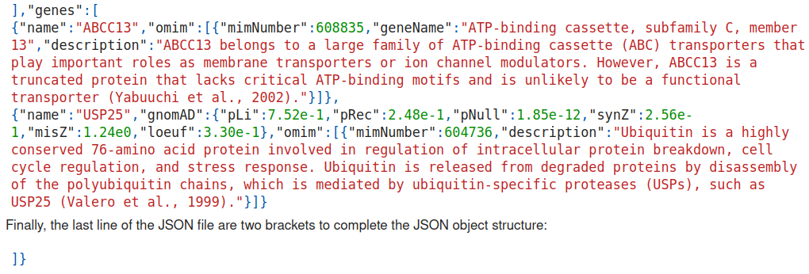

```r
genes[c(1:77)] |>
  lapply(function(x) as.data.frame(fromJSON(x)) %>%
           {
             if(c("omim.phenotypes") %in% names(.)) tidyr::unnest(., cols=c( omim.phenotypes), names_sep = "_") else .
           }
  )  %>%
  bind_rows() %>%
  rename("_________________________omim.description____________________________"= omim.description,
         "____________________omim.phenotypes_description______________________"= omim.phenotypes_description) %>%
    mutate(`__Accession__` = case_when(stringr::str_detect(name, "\\.") ~
                                                stringr::str_extract(name, ".*(?=\\.\\d$)"),
                                     TRUE ~ name)) %>%

  select(`__Accession__`, name, omim.geneName, clingenGeneValidity.classification, everything()) %>%
  DT::datatable(options = list(scrollX = TRUE, autoWidth = TRUE,
                               columnDefs = list(list(className = 'dt-center', targets = "_all"),
                                                 list(width = '650px', targets= list(11,  14)),
                                                 list(width = '200px', targets= list(9,  10)))
  ),
  rownames = FALSE
  ) #%>%
```

| __Accession__ | name | omim.geneName | clingenGeneValidity.classification | gnomAD.pLi | gnomAD.pRec | gnomAD.pNull | gnomAD.synZ | gnomAD.misZ | gnomAD.loeuf | omim.mimNumber | clingenDosageSensitivityMap.haploinsufficiency | clingenDosageSensitivityMap.triplosensitivity | _________________________omim.description____________________________ | omim.phenotypes_mimNumber | omim.phenotypes_phenotype | ____________________omim.phenotypes_description______________________ | omim.phenotypes_mapping | omim.phenotypes_inheritances | omim.phenotypes_comments | clingenGeneValidity.diseaseId | clingenGeneValidity.disease | clingenGeneValidity.classificationDate |
| --- | --- | --- | --- | --- | --- | --- | --- | --- | --- | --- | --- | --- | --- | --- | --- | --- | --- | --- | --- | --- | --- | --- |
| ACAP3 | ACAP3 |  |  | 4.41e-06 | 1 | 1.49e-05 | -1.4 | 1.67 | 0.586 |  |  |  |  |  |  |  |  |  |  |  |  |  |
| ACTRT2 | ACTRT2 | Actin-related protein T2 |  | 0.000477 | 0.689 | 0.311 | -1.12 | -0.403 | 1.38 | 608535 |  |  |  |  |  |  |  |  |  |  |  |  |
| AGRN | AGRN | Agrin |  | 5.47e-07 | 1 | 1.41e-12 | -3.96 | 0.226 | 0.435 | 103320 | gene associated with autosomal recessive phenotype | no evidence to suggest that dosage sensitivity is associated with clinical phenotype | The AGRN gene encodes agrin, a large and ubiquitous proteoglycan with multiple isoforms that have diverse functions in different tissues. Agrin was originally identified as an essential neural regulat… | 615120 | Myasthenic syndrome, congenital, 8, with pre- and postsynaptic defects | Congenital myasthenic syndromes are genetic disorders of the neuromuscular junction (NMJ) that are classified by the site of the transmission defect: presynaptic, synaptic, and postsynaptic. CMS8 is a… | molecular basis of the disorder is known | ['Autosomal recessive'] |  |  |  |  |
| AJAP1 | AJAP1 | Adherens junction-associated protein 1 |  | 0.995 | 0.00531 | 5.54e-07 | 0.163 | 0.936 | 0.192 | 610972 |  |  |  |  |  |  |  |  |  |  |  |  |
| AL590822 | AL590822.1 |  |  |  |  |  | -0.854 | -0.859 |  |  |  |  |  |  |  |  |  |  |  |  |  |  |
| AL590822 | AL590822.2 |  |  |  |  |  | 1.42 | 1.26 |  |  |  |  |  |  |  |  |  |  |  |  |  |  |
| AL627309 | AL627309.1 |  |  | 0.000906 | 0.586 | 0.413 | 0.109 | -0.777 | 1.61 |  |  |  |  |  |  |  |  |  |  |  |  |  |
| AL645608 | AL645608.1 |  |  | 0.0121 | 0.661 | 0.327 | -1.37 | -0.645 | 1.7 |  |  |  |  |  |  |  |  |  |  |  |  |  |
| AL645728 | AL645728.1 |  |  |  |  |  | 0.217 | 0.152 |  |  |  |  |  |  |  |  |  |  |  |  |  |  |
| ANKRD65 | ANKRD65 |  |  | 5.06e-09 | 0.0178 | 0.982 | -0.0354 | 0.592 | 1.96 |  |  |  |  |  |  |  |  |  |  |  |  |  |

[output cut: 73 more lines]

```r
  #DT::formatStyle(columns = c(11, 14), width='650px')
```

- The column `variants.transcripts_hgnc` in `Positions` object has commun parttern with `name` column in `genes` object.
- We mutate a new column named `__Accession__` to extract only commun pattern

# 4 Python environment

This is specific to Rstudio computing environments (IDE).

```bash
which python3
```

```r
# Set python environment and version in RStudio ;-)
reticulate::use_python("/usr/bin/python3", required = TRUE)
reticulate::py_config()
```

```
## python:         /usr/bin/python3
## libpython:      /usr/lib/python3.10/config-3.10-x86_64-linux-gnu/libpython3.10.so
## pythonhome:     //usr://usr
## version:        3.10.6 (main, Nov 14 2022, 16:10:14) [GCC 11.3.0]
## numpy:          /usr/lib/python3/dist-packages/numpy
## numpy_version:  1.21.5
##
## NOTE: Python version was forced by use_python function
```

```python
import gzip

header = ''
positions = []
genes = []
is_header_line = True
is_position_line = False
is_gene_line = False
gene_section_line = '],"genes":['
end_line = ']}'
with gzip.open('HiSeq.10000.json.gz', 'rt') as f:
    position_count = 0
    gene_count = 0
    for line in f:
        trim_line = line.strip()
        if is_header_line:
            ## only keep the "header" field content from the line
            header = trim_line[10:-14]
            is_header_line = False
            is_position_line = True
            continue
        if trim_line == gene_section_line:
            is_gene_line = True
            is_position_line = False
            continue
        elif trim_line == end_line:
            break
        else:
            if is_position_line:
                ## remove the trailing ',' if there is
                positions.append(trim_line.rstrip(','))
                position_count += 1
            if is_gene_line:
                ## remove the trailing ',' if there is
                genes.append(trim_line.rstrip(','))
                gene_count += 1

#print ('header object:', header)
print ('number of positions:', position_count)
```

```
## number of positions: 9966
```

```python
print ('number of genes:', gene_count)
```

```
## number of genes: 77
```

```r
print("The first five objects of the header")
```

```
## [1] "The first five objects of the header"
```

```r
jsonlite::fromJSON(reticulate::py$header)[1:5]
```

```
## $annotator
## [1] "Nirvana 3.12.0"
##
## $creationTime
## [1] "2020-11-13 17:09:01"
##
## $genomeAssembly
## [1] "GRCh37"
##
## $schemaVersion
## [1] 6
##
## $dataVersion
## [1] "91.27.60"
```

```r
DT::datatable(jsonlite::fromJSON(reticulate::py$header)[6][[1]], caption = 'The sixth object of the header')
```

|  | name | version | description | releaseDate |
| --- | --- | --- | --- | --- |
| 1 | VEP | 91 | BothRefSeqAndEnsembl | 2017-12-18 |
| 2 | MultiZ100Way | 20150427 | Amino acid conservation scores calculated from MultiZ100Way alignments from UCSC. | 2015-04-27 |
| 3 | ClinVar | 20200903 | A freely accessible, public archive of reports of the relationships among human variations and phenotypes, with supporting evidence | 2020-09-03 |
| 4 | dbSNP | 154 | Identifiers for observed variants | 2020-05-01 |
| 5 | dbSNP | 151 | Identifiers for observed variants | 2018-04-23 |
| 6 | gnomAD | 2.1 | Allele frequencies from Genome Aggregation Database (gnomAD) | 2018-10-17 |
| 7 | MITOMAP | 20200819 | Small variants in the MITOMAP human mitochondrial genome database | 2020-08-19 |
| 8 | 1000 Genomes Project | Phase 3 v5a | A public catalogue of human variation and genotype data | 2013-05-27 |
| 9 | PrimateAI | 0.2 | PrimateAI percentile scores. | 2018-11-07 |
| 10 | REVEL | 20200205 | Pathogenicity scores of missense variants predicted by REVEL | 2020-02-05 |

[output cut: 12 more lines]

### 4.0.1 Retrieve variants under a gnomAD allele frequency threshold

```python
import pandas as pd
import json

variants_field = 'variants'
gnomad_field = 'gnomad'
freq_threshold = 0.0001
freq_data = {'variant_id': [], 'gnomAD_allele_freq': []}
for position in positions:
    position_dict = json.loads(position)
    if variants_field in position_dict:
        for variant_dict in position_dict[variants_field]:
            if gnomad_field in variant_dict:
                freq = variant_dict[gnomad_field]['allAf']
                if freq < freq_threshold:
                    freq_data['variant_id'].append(variant_dict['vid'])
                    freq_data['gnomAD_allele_freq'].append(freq)

freq_df = pd.DataFrame(data=freq_data)
```

```r
DT::datatable(reticulate::py$freq_df)
```

|  | variant_id | gnomAD_allele_freq |
| --- | --- | --- |
| 1 | 1-526910-C-T | 8.3e-05 |
| 2 | 1-714991-A-G | 3.2e-05 |
| 3 | 1-797375-A-G | 6.4e-05 |
| 4 | 1-806588-A-G | 6.4e-05 |
| 5 | 1-807561-A-T | 3.2e-05 |
| 6 | 1-811378-C-T | 0 |
| 7 | 1-813729-G-A | 3.2e-05 |
| 8 | 1-814233-G-A | 0 |
| 9 | 1-814720-T-C | 3.2e-05 |
| 10 | 1-814787-A-G | 9.6e-05 |

[output cut: 97 more lines]

### 4.0.2 Retrieve all relevant genes and their OMIM gene names

```python
gene_data = {'gene': [], 'OMIM_gene_name': [], 'Description': []}
for gene in genes:
    gene_dict = json.loads(gene)
    gene_data['gene'].append(gene_dict['name'])
    omim_gene_name = ''
    description = ''
    if 'omim' in gene_dict:
        omim_dict = gene_dict['omim'][0]
        if 'geneName' in omim_dict:
            omim_gene_name = omim_dict['geneName']
        if 'description' in omim_dict:
            description = omim_dict['description']
    gene_data['OMIM_gene_name'].append(omim_gene_name)
    gene_data['Description'].append(description)
gene_df=pd.DataFrame(data=gene_data)
```

```r
library(reticulate)
DT::datatable(reticulate::py$gene_df)
```

|  | gene | OMIM_gene_name | Description |
| --- | --- | --- | --- |
| 1 | ACAP3 |  |  |
| 2 | ACTRT2 | Actin-related protein T2 |  |
| 3 | AGRN | Agrin | The AGRN gene encodes agrin, a large and ubiquitous proteoglycan with multiple isoforms that have diverse functions in different tissues. Agrin was originally identified as an essential neural regulat… |
| 4 | AJAP1 | Adherens junction-associated protein 1 |  |
| 5 | AL590822.1 |  |  |
| 6 | AL590822.2 |  |  |
| 7 | AL627309.1 |  |  |
| 8 | AL645608.1 |  |  |
| 9 | AL645728.1 |  |  |
| 10 | ANKRD65 |  |  |

[output cut: 67 more lines]

# 5 Visualize json file with circos (circular heatmap) layout

This is may be useful to visualize json output from NGS.

## 5.1 useful packages

- shiny.gosling
- [radial_heatMap_generator](https://github.com/wjsutton/radial_heatmap_generator)
- [circulize](https://cran.r-project.org/web/packages/circlize/index.html)
- [CoffeeWheel](https://github.com/armish/coffeewheel)
- Glimpse the structre of json file used by `shiny.gosling`

```r
jsonlite::fromJSON(txt = "data/server.gosling-lang.org.json") |> str()
```

```
## List of 1
##  $ cistrome-multivec:List of 10
##   ..$ resolutions : int [1:15] 16384000 8192000 4096000 2048000 1024000 512000 256000 128000 64000 32000 ...
##   ..$ min_pos     : int 0
##   ..$ max_pos     : num 3.21e+09
##   ..$ tile_size   : int 256
##   ..$ shape       : int [1:2] 256 228
##   ..$ row_infos   : chr [1:228] "Homo sapiens\tTH1_K27AC_REP2\tGSM2048305\tGSE77299\tNone\tTh1\tTonsil\tNone\tH3K27ac\thm\tNone" "Homo sapiens\tH3K27AC_CHIPSEQ_HUMAN_REP1\tGSM1375210\tGSE49624\tNone\tSpermatid\tNone\tACTIVE MOTIF\tH3K27ac\thm\tNone" "Homo sapiens\tILC1_K27AC_REP2\tGSM2048292\tGSE…
##   ..$ name        : chr "my_file_genome_wide.multires.mv5"
##   ..$ datatype    : chr "multivec"
##   ..$ coordSystem : chr ""
##   ..$ coordSystem2: chr ""
```

```r
jsonlite::fromJSON(txt = "data/server.gosling-lang.org.json")[[1]][6] |> as.data.frame() |>
  tidyr::separate(col = row_infos, into = c("espece", "Ref1", "Ref2", "Ref3",
                                            "Ref4", "Ref5", "Ref6", "Ref7",
                                            "Ref8", "Ref9", "Ref11"), sep = "[^[:alnum:] ]+") |>
    DT::datatable(options = list(scrollX = TRUE,
                               columnDefs = list(list(className = 'dt-center', targets = "_all"))
  ),
  rownames = FALSE)
```

| espece | Ref1 | Ref2 | Ref3 | Ref4 | Ref5 | Ref6 | Ref7 | Ref8 | Ref9 | Ref11 |
| --- | --- | --- | --- | --- | --- | --- | --- | --- | --- | --- |
| Homo sapiens | TH1 | K27AC | REP2 | GSM2048305 | GSE77299 | None | Th1 | Tonsil | None | H3K27ac |
| Homo sapiens | H3K27AC | CHIPSEQ | HUMAN | REP1 | GSM1375210 | GSE49624 | None | Spermatid | None | ACTIVE MOTIF |
| Homo sapiens | ILC1 | K27AC | REP2 | GSM2048292 | GSE77299 | None | ILC1 | Tonsil | None | H3K27ac |
| Homo sapiens | TH17 | K27AC | REP2 | GSM2048310 | GSE77299 | None | Th17 | Tonsil | None | H3K27ac |
| Homo sapiens | IP | H3K27AC | 797 | REP1 | JUN2014 | GSM1820938 | GSE70870 | TC | 797 | None |
| Homo sapiens | IP | H3K27AC | 797 | REP2 | JUN2014 | GSM1820939 | GSE70870 | TC | 797 | None |
| Homo sapiens | H3K27AC | CHIPSEQ | REP2 | A | GSM1057020 | GSE43036 | None | Monocyte | Blood | H3K27ac |
| Homo sapiens | H3K27AC | CHIPSEQ | REP2 | B | GSM1057021 | GSE43036 | None | Monocyte | Blood | H3K27ac |
| Homo sapiens | H3K27AC | CHIPSEQ | REP2 | D | GSM1057023 | GSE43036 | None | Monocyte | Blood | H3K27ac |
| Homo sapiens | NK H3K27AC DONOR A | GSM999008 | GSE40668 | None | Natural Killer Cell | Blood | abcam | ab4729 | GR45851 | 1 |

[output cut: 218 more lines]

```r
file <- jsonlite::fromJSON("data/server.gosling-lang.org.json")


file |>
  purrr::map(as.data.table) |>
  rbindlist(fill=TRUE, idcol = TRUE) |>
  tidyr::separate(col = row_infos, into = c("info1", "info2", "info3", "info4",
                                            "info5", "info6", "innfo7", "info8",
                                            "info9", "info10", "info11"), sep = "[^[:alnum:] ]+") |>
  DT::datatable(options = list(scrollX = TRUE,
                               columnDefs = list(list(className = 'dt-center', targets = "_all"))
  ),
  rownames = FALSE)
```

| .id | resolutions | min_pos | max_pos | tile_size | shape | info1 | info2 | info3 | info4 | info5 | info6 | innfo7 | info8 | info9 | info10 | info11 | name | datatype | coordSystem | coordSystem2 |
| --- | --- | --- | --- | --- | --- | --- | --- | --- | --- | --- | --- | --- | --- | --- | --- | --- | --- | --- | --- | --- |
| cistrome-multivec | 16384000 | 0 | 3209286105 | 256 | 256 | Homo sapiens | TH1 | K27AC | REP2 | GSM2048305 | GSE77299 | None | Th1 | Tonsil | None | H3K27ac | my_file_genome_wide.multires.mv5 | multivec |  |  |
| cistrome-multivec | 8192000 | 0 | 3209286105 | 256 | 228 | Homo sapiens | H3K27AC | CHIPSEQ | HUMAN | REP1 | GSM1375210 | GSE49624 | None | Spermatid | None | ACTIVE MOTIF | my_file_genome_wide.multires.mv5 | multivec |  |  |
| cistrome-multivec | 4096000 | 0 | 3209286105 | 256 | 256 | Homo sapiens | ILC1 | K27AC | REP2 | GSM2048292 | GSE77299 | None | ILC1 | Tonsil | None | H3K27ac | my_file_genome_wide.multires.mv5 | multivec |  |  |
| cistrome-multivec | 2048000 | 0 | 3209286105 | 256 | 228 | Homo sapiens | TH17 | K27AC | REP2 | GSM2048310 | GSE77299 | None | Th17 | Tonsil | None | H3K27ac | my_file_genome_wide.multires.mv5 | multivec |  |  |
| cistrome-multivec | 1024000 | 0 | 3209286105 | 256 | 256 | Homo sapiens | IP | H3K27AC | 797 | REP1 | JUN2014 | GSM1820938 | GSE70870 | TC | 797 | None | my_file_genome_wide.multires.mv5 | multivec |  |  |
| cistrome-multivec | 512000 | 0 | 3209286105 | 256 | 228 | Homo sapiens | IP | H3K27AC | 797 | REP2 | JUN2014 | GSM1820939 | GSE70870 | TC | 797 | None | my_file_genome_wide.multires.mv5 | multivec |  |  |
| cistrome-multivec | 256000 | 0 | 3209286105 | 256 | 256 | Homo sapiens | H3K27AC | CHIPSEQ | REP2 | A | GSM1057020 | GSE43036 | None | Monocyte | Blood | H3K27ac | my_file_genome_wide.multires.mv5 | multivec |  |  |
| cistrome-multivec | 128000 | 0 | 3209286105 | 256 | 228 | Homo sapiens | H3K27AC | CHIPSEQ | REP2 | B | GSM1057021 | GSE43036 | None | Monocyte | Blood | H3K27ac | my_file_genome_wide.multires.mv5 | multivec |  |  |
| cistrome-multivec | 64000 | 0 | 3209286105 | 256 | 256 | Homo sapiens | H3K27AC | CHIPSEQ | REP2 | D | GSM1057023 | GSE43036 | None | Monocyte | Blood | H3K27ac | my_file_genome_wide.multires.mv5 | multivec |  |  |
| cistrome-multivec | 32000 | 0 | 3209286105 | 256 | 228 | Homo sapiens | NK H3K27AC DONOR A | GSM999008 | GSE40668 | None | Natural Killer Cell | Blood | abcam | ab4729 | GR45851 | 1 | my_file_genome_wide.multires.mv5 | multivec |  |  |

[output cut: 218 more lines]

```r
structureVariant <- readr::read_csv("data/structureVariant.csv", show_col_types = FALSE)

structureVariant |>
    DT::datatable(options = list(scrollX = TRUE,
                               columnDefs = list(list(className = 'dt-center', targets = "_all"))
  ),
  rownames = FALSE)
```

| chr1 | start1 | end1 | chr2 | start2 | end2 | id/name | brass_score | strand1 | strand2 | sample | svclass | bkdist | assembly_score | readpair names | readpair count | bal_trans | inv | occL | occH | copynumber_flag | range_blat | Brass Notation | non-template | micro-homology | assembled readnames | assembled read count | gene1 | gene_id1 | transcript_id1 | … |
| --- | --- | --- | --- | --- | --- | --- | --- | --- | --- | --- | --- | --- | --- | --- | --- | --- | --- | --- | --- | --- | --- | --- | --- | --- | --- | --- | --- | --- | --- | --- |
| 1 | 1221574 | 1221575 | 3 | 36001515 | 36001516 | 2 | 4 | + | - | PD35930a | translocation | -1 | _ | HX6_22491:1:2102:16843:31160,HX6_22527:4:1119:17726:45804,HX6_22527:5:1111:18233:6601,HX8_22556:8:1222:27377:57600 | 4 | 0 | 0 | 1 | 1 | 0 | 0 | _ | _ | _ | _ | _ | SCNN1D | SCNN1D | ENST00000379116 | … |
| 1 | 9257519 | 9257520 | 3 | 82441834 | 82441835 | 3 | 16 | + | + | PD35930a | translocation | -1 | _ | HX3_22561:4:2110:15564:52572,HX3_22562:5:2214:19867:48986,HX3_22562:6:1209:16650:17641,HX3_22562:8:1201:22211:65353,HX6_22491:5:1101:15361:41708,HX6_22567:3:2104:1529:62224,HX6_22567:3:2211:29122:6853… | 16 | 0 | 0 | 1 | 1 | 1 | 0 | _ | _ | _ | _ | _ | RP3-510D11.1 | RP3-510D11.1 | ENST00000437157 | … |
| 1 | 16246581 | 16246582 | 1 | 16252110 | 16252111 | 4 | 21 | + | + | PD35930a | deletion | 5528 | 100 | HX3_22561:4:2118:28990:55332,HX3_22561:6:2220:17746:71541,HX3_22561:7:1221:5345:37401,HX3_22562:7:1219:27011:72578,HX3_22562:8:1117:23115:27644,HX6_22491:2:1222:5781:66988,HX6_22491:4:1116:25581:53680… | 21 | 0 | 0 | 1 | 1 | 1 | 0 | Chr.1 16246582] AATAAA [16252111 Chr.1 (score 100) | AATAAA | . | HX7_22510:6:1206:7882:42429/1,HX6_22567:2:2208:25175:39159/1,HX6_22567:6:2210:29894:67410/2,HX3_22562:7:1219:27011:72578/1,HX6_22567:2:1115:4614:57055/1,HX3_22562:4:2211:12916:21157/2,HX7_22510:1:1108… | 10 | SPEN | SPEN | ENST00000375759 | … |
| 1 | 32018492 | 32018495 | 1 | 43449929 | 43449932 | 5 | 25 | - | - | PD35930a | tandem-duplication | 11431434 | 99 | HX3_22561:3:1207:23145:33076,HX3_22561:5:1115:19360:48177,HX3_22561:6:1211:18873:34711,HX3_22561:6:1220:26413:67217,HX3_22561:8:1208:28097:43097,HX3_22562:5:2114:28402:17571,HX6_22491:5:1208:1793:6232… | 25 | 0 | 0 | 1 | 1 | 1 | 0 | Chr.1- 32018495(93)--TT--43449932(30) Chr.1- (score 99) | . | TT | HX7_22509:4:2106:30766:21104/2,HX8_22555:3:2119:22161:5950/1,HX6_22491:8:2202:29843:32338/1,HX7_22510:4:1120:10592:57003/2,HX8_22555:8:2117:3254:25024/1,HX3_22562:6:2219:9638:34887/2,HX7_22510:8:2115:… | 13 | _ | _ | _ | … |
| 1 | 32164475 | 32164481 | 1 | 32422251 | 32422257 | 6 | 16 | + | + | PD35930a | deletion | 257770 | 100 | HX3_22561:5:2201:1884:14107,HX3_22561:7:2109:15554:66021,HX3_22561:8:1101:28686:21087,HX6_22527:4:1203:20669:43765,HX6_22567:1:2102:27590:38948,HX6_22567:3:2104:9394:31125,HX7_22509:1:1114:18720:19504… | 16 | 0 | 0 | 1 | 1 | 1 | 0 | Chr.1 32164476(81)--CTGAG--32422252(57) Chr.1 (score 100) | . | CTGAG | HX8_22556:2:2219:4107:16270/1,HX8_22556:1:1105:31416:10556/1,HX6_22491:4:2220:30817:52344/1,HX6_22527:5:2111:22729:12209/2,HX6_22567:1:2102:27590:38948/2,HX3_22561:7:2109:15554:66021/1 | 6 | COL16A1 | COL16A1 | ENST00000373672 | … |
| 1 | 79835345 | 79835346 | 1 | 79857842 | 79857843 | 8 | 14 | + | + | PD35930a | deletion | 22496 | _ | HX3_22561:4:2124:17269:49935,HX3_22561:7:1114:14194:3014,HX3_22561:7:1210:27996:27837,HX3_22562:1:2103:20019:26747,HX3_22562:3:1211:15361:27152,HX6_22491:1:2108:10612:64878,HX6_22567:7:1210:17137:2452… | 14 | 0 | 0 | 1 | 1 | 1 | 0 | _ | _ | _ | _ | _ | _ | _ | _ | … |
| 1 | 82939873 | 82939874 | 2 | 109382279 | 109382280 | 9 | 12 | - | + | PD35930a | translocation | -1 | _ | HX3_22562:2:2209:6248:17623,HX3_22562:5:1116:6451:28031,HX3_22562:7:1120:30289:5546,HX6_22491:4:2219:19421:67129,HX6_22491:7:1121:30188:41831,HX7_22509:1:1103:24271:52186,HX7_22509:4:1117:31132:25323,… | 12 | 0 | 0 | 2 | 2 | 0 | 0 | _ | _ | _ | _ | _ | _ | _ | _ | … |
| 1 | 82939873 | 82939874 | 22 | 31836022 | 31836023 | 10 | 8 | - | - | PD35930a | translocation | -1 | 100 | HX3_22561:8:2224:16325:38807,HX6_22491:7:1203:31416:3700,HX6_22527:3:1111:30107:3507,HX6_22527:3:1218:20689:17606,HX6_22567:1:2222:20963:57249,HX6_22567:3:1118:14275:26396,HX7_22510:7:2216:16193:55245… | 8 | 0 | 0 | 2 | 2 | 1 | 0 | Chr.1- 82939874][31836023 Chr.22- (score 100) | . | . | HX6_22491:3:2202:20831:14617/2,HX3_22562:7:1120:30289:5546/1,HX8_22556:3:1217:3214:53012/2,HX6_22527:1:2201:9151:72156/1,HX6_22567:3:2106:14103:56194/2,HX8_22556:3:1217:3214:52942/2,HX3_22562:5:1116:6… | 12 | _ | _ | _ | … |
| 1 | 82940713 | 82940714 | 22 | 31835874 | 31835875 | 12 | 5 | - | + | PD35930a | translocation | -1 | _ | HX3_22562:1:2203:3051:66759,HX3_22562:7:2103:4188:39827,HX7_22509:6:2109:31527:73299,HX7_22510:7:2116:8258:1274,HX8_22556:8:1121:25408:64597 | 5 | 0 | 0 | 1 | 2 | 0 | 0 | _ | _ | _ | _ | _ | _ | _ | _ | … |
| 1 | 82940713 | 82940717 | 2 | 109382570 | 109382574 | 11 | 15 | - | - | PD35930a | translocation | -1 | 95 | HX3_22561:1:1102:25915:70117,HX3_22562:1:1201:30797:50832,HX3_22562:1:1212:5649:44925,HX3_22562:1:2206:5710:16938,HX3_22562:8:1113:30685:21174,HX3_22562:8:2224:5000:56211,HX6_22491:4:1103:31933:50023,… | 15 | 0 | 0 | 1 | 2 | 1 | 0 | Chr.1- 82940717(14)--TTG--109382574(71) Chr.2- (score 95) | . | TTG | HX3_22562:7:1120:30289:5546/2,HX3_22562:7:1120:30665:5106/2,HX7_22510:7:2116:8258:1274/2,HX6_22527:2:1217:7537:68342/1,HX6_22527:1:2201:9151:72156/2,HX7_22510:8:2202:4949:49232/2,HX3_22561:8:2221:1001… | 8 | _ | _ | _ | … |

[output cut: 144 more lines]